# Predictability of storm surge and Chesapeake Bay flooding: from days to weeks Notebook

[figure not shown]

### Description:

- Run the iFlood SubX forecast system over a period for which SubX re-forecasts have been produced (1999-2015) to evaluate the overall predictability statistics of sea-level predictions at sites along the Chesapeake Bay where historical tide gauge data is available for validation, and the predictability at various lead times for individual events.
- Evaluation of the predictability at the daily, weekly, up to 1-month timescale of the key variables, forecasted by the SubX models, that are needed to force the Mason iFlood system - namely 10-meter winds and sea-level pressure over the western North Atlantic. For this task we will look at the overall predictability statistics for the 1999-2015 re-forecast period over which the global weather and climate models participating in the SubX project have been run. We will evaluate the skill of the multi-model mean as well as the respective model ensembles.
- We used GEFS ensemble 10 to test as a forcing for our system. It is then being compared with the Validated Data provided.

### Import Libraries and assign variables

```python
import utils
utils.libs();
qc_staff = 'Tyler Miesse'
root_dir = r'Z:\Project_S2S\3_subx_data\isabel\comparison'
root_dir2 = r'Z:\Project_S2S\3_subx_data\isabel\comparison\no_tidal'
files,tidal,start,nodes,name,stations = utils.files(root_dir,root_dir2)
```

### Verified Pressure data

[figure not shown]

#### Weeks 1-4

[figure not shown]

```python
title = 'Week4 Atmospheric Pressure'
lat1,lat2 = 25, 44
lon1,lon2 = -82.5, -62
f73 = os.path.join(root_dir2,'week4\\fort.73.nc')
file3 = nc4.Dataset(f73)
hours = 810
start = '2003082700'
levels = np.arange(10.1,10.55, 0.075)
adcirc.global_pressure(root_dir,file3,title,hours,levels,lon1,lon2,lat1,lat2,start)
```

```python
title = 'Week3 Atmospheric Pressure'
lat1,lat2 = 25, 44
lon1,lon2 = -82.5, -62
f73 = os.path.join(root_dir2,'week3\\fort.73.nc')
file3 = nc4.Dataset(f73)
hours = 810
start = '2003090300'
levels = np.arange(10.1,10.55, 0.075)
adcirc.global_pressure(root_dir,file3,title,hours,levels,lon1,lon2,lat1,lat2,start)
```

```python
title = 'Week2 Atmospheric Pressure'
lat1,lat2 = 25, 44
lon1,lon2 = -82.5, -62
f73 = os.path.join(root_dir2,'week2\\fort.73.nc')
file3 = nc4.Dataset(f73)
hours = 810
start = '2003091000'
levels = np.arange(10.1,10.55, 0.075)
adcirc.global_pressure(root_dir,file3,title,hours,levels,lon1,lon2,lat1,lat2,start)
```

```python
title = 'Week1 Atmospheric Pressure'
lat1,lat2 = 25, 44
lon1,lon2 = -82.5, -62
f73 = os.path.join(root_dir2,'week1\\fort.73.nc')
file3 = nc4.Dataset(f73)
hours = 810
start = '2003091700'
levels = np.arange(10.1,10.55, 0.075)
adcirc.global_pressure(root_dir,file3,title,hours,levels,lon1,lon2,lat1,lat2,start)
```

### Water Level from Weeks 1-4

```python
data = utils.surge(files,nodes,start,name)
layout = go.Layout(dict(title = 'S2S 1-4 Weeks'),
          xaxis = dict(title = 'Time'),yaxis = dict(title = 'Water level (m) at MSL'),
          legend= dict(orientation = "h"),font = dict(color = 'rgb(0,0,0)'),
          paper_bgcolor = 'rgb(255,255,255)',plot_bgcolor = 'rgb(255,255,255)')
fig = go.Figure(data=data, layout=layout)
interactive = iplot(fig)
#po.plot(fig,filename=root_dir+'\\'+'duck_tidal.html')
```

[interactive chart not shown]

## Surge from Weeks 1-4

Compare the predictability metrics and skill at various lead times for different types of extreme weather phenomena associated with storm surge events along the mid-Atlantic coast and flooding events in the Chesapeake Bay.

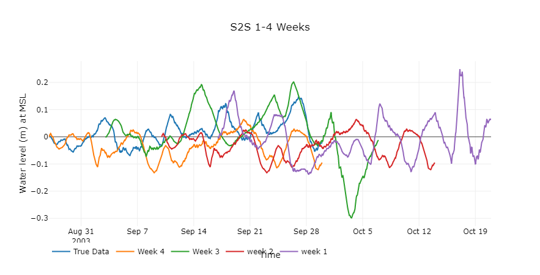

```python
data = utils.surge(files,nodes,start,name)
layout = go.Layout(dict(title = 'S2S 1-4 Weeks'),
          xaxis = dict(title = 'Time'),yaxis = dict(title = 'Water level (m) at MSL'),
          legend= dict(orientation = "h"),font = dict(color = 'rgb(0,0,0)'),
          paper_bgcolor = 'rgb(255,255,255)',plot_bgcolor = 'rgb(255,255,255)')
fig = go.Figure(data=data, layout=layout)
interactive = iplot(fig)
```

```python
nc_file = nc4.Dataset(files[0])
start,freq = '20030827 00:00:00','1H'
station,names = 26642,' Prediction'
table = utils.timeseries(nc_file,start,freq,station,names)
start,end,noaa = '20030827','20030926','8651370'
data = utils.plot_timeseries(table,start,end,noaa,name,26642)
title,x,y = '2003 Hurricane Isabel','Time','Water level (m) at MSL'
layout=utils.layout(title,x,y)
fig = go.Figure(data=data, layout=layout)
interactive = iplot(fig)
```

[output not shown]

[output cut: 23 more lines]

[output not shown]

### Duck, NC Station

```python
data = utils.sub_tidal2surge(files,nodes,start,name,tidal)
layout = go.Layout(dict(title = 'S2S 1-4 Weeks'),
          xaxis = dict(title = 'Time'),yaxis = dict(title = 'Surge height (m) MSL'),
          legend= dict(orientation = "h"),font = dict(color = 'rgb(0,0,0)'),
          paper_bgcolor = 'rgb(255,255,255)',plot_bgcolor = 'rgb(255,255,255)')
fig = go.Figure(data=data, layout=layout)
interactive = iplot(fig)
#po.plot(fig,filename=root_dir+'\\'+'duck_surge.html')
```

[interactive chart not shown]

### Ocean City, MD

```python
data = utils.sub_tidal2surge(files,nodes,start,name,tidal)
layout = go.Layout(dict(title = 'S2S 1-4 Weeks'),
          xaxis = dict(title = 'Time'),yaxis = dict(title = 'Surge height (m) MSL'),
          legend= dict(orientation = "h"),font = dict(color = 'rgb(0,0,0)'),
          paper_bgcolor = 'rgb(255,255,255)',plot_bgcolor = 'rgb(255,255,255)')
fig = go.Figure(data=data, layout=layout)
interactive = iplot(fig)
po.plot(fig,filename=root_dir+'\\'+'oceancity_surge.html')
```

[interactive chart not shown]

```
'file://Z:\\Project_S2S\\3_subx_data\\isabel\\comparison\\oceancity_surge.html'
```

```python
data = []
for f in range(0,len(files)):
    if f>len(files):
        water_level = pd.read_csv(stations[0]['Duck'])
        wl = pd.read_csv(stations[0]['Duck2'])
        wl.rename(columns={' Prediction':' Water Level'})
        surge = pd.DataFrame()
        surge.insert(0,'Date Time',water_level['Date Time'])
        surge.insert(1,' Water Level',np.zeros(len(water_level)))
    else:
        wl  = nc4.Dataset(tidal[f])
        wl = wl['zeta'][:,nodes[0]]
        wl = pd.DataFrame(wl)
        tidal_dt=pd.date_range(start=start[f],periods=int(len(wl)),freq='1H')
        wl.insert(0,'Date Time',tidal_dt)
        wl=wl.rename(columns={0:' Water Level'})
        nc_file = nc4.Dataset(files[f])
        water_level = nc_file['zeta'][:,nodes]
        water_level = pd.DataFrame(water_level)
        date_time = pd.date_range(start=start[f],periods=int(len(water_level)),freq='1H')
        water_level.insert(0,'Date Time',date_time)
        water_level=water_level.rename(columns={0:' Water Level'})
        surge = pd.DataFrame()
        surge.insert(0,'Date Time',date_time)
        surge.insert(1,' Water Level',np.zeros(len(water_level)))
    c_list = ['rgba(51, 204, 51)','rgba(0, 255, 204)',
              'rgba(0, 204, 255)','rgba(102, 255, 255)',
              'rgba(0, 102, 153)','rgba(0, 0, 255)',
              'rgba(51, 51, 255)','rgba(102, 0, 255)',
              'rgba(153, 153, 255)','rgba(204, 0, 255)',
              'rgba(255, 51, 204)','rgba(204, 0, 0)',
              'rgba(255, 153, 0)','rgba(204, 255, 51)',
              'rgba(0, 153, 0)']
    for x in range(1):
            y=random.randint(1,14)
            color = c_list[y]

    for ii in range(len(water_level[' Water Level'])):
        if (water_level[' Water Level'][ii]-wl[' Water Level'][ii])==np.max(water_level[' Water Level'][15:]-wl[' Water Level'][15:len(water_level)]):
            for i3 in range(ii-5,ii+5):
                surge[' Water Level'][i3]=abs(water_level[' Water Level'][i3]-wl[' Water Level'][i3])
    trace = go.Scatter(x =surge['Date Time'],y =surge[' Water Level'],
                name = name[f],mode = 'lines',
                line = dict(
                    color = (color)))
    data.append(trace)
```

```python
layout = go.Layout(dict(title = 'S2S 1-4 Weeks'),
          xaxis = dict(title = 'Time'),yaxis = dict(title = 'Surge height (m) MSL'),
          legend= dict(orientation = "h"),font = dict(color = 'rgb(0,0,0)'),
          paper_bgcolor = 'rgb(255,255,255)',plot_bgcolor = 'rgb(255,255,255)')
fig = go.Figure(data=data, layout=layout)
interactive = iplot(fig)
po.plot(fig,filename=root_dir+'\\'+'surge.html')
```

[interactive chart not shown]

```
'file://Z:\\Project_S2S\\3_subx_data\\isabel\\comparison\\surge.html'
```